# Brassica growth under fertiliser and mite infestation

Margarida Antunes

2023-06-06

# Data and packages

```r
library(tidyverse)
library(lme4)
library(car)
library(emmeans)
```

```r
data <- read.csv("data/data2.csv", sep = ";", na.strings = "NA") %>%
  mutate(Mite_ID = factor(Mite_ID),
         # growth between measurements
         H1_H2 = P_height_2 - P_height,
         H2_H3 = P_height_3 - P_height_2,
         L1_L2 = P_leaves_2 - P_leaves,
         L2_L3 = P_leaves_3 - P_leaves_2,
         P1_P2 = P_pistil_VIZ_2 - P_pistil_VIZ,
         P2_P3 = P_pistil_VIZ_3 - P_pistil_VIZ_2)
```

# Data preparation

Plants were measured at three time points (weeks 4, 6 and 7). The data are reshaped from one row per plant to one row per plant per time point.

```r
# Measurements from one time point (n = 1, 2 or 3)
timepoint <- function(n, week) {
  sfx <- if (n == 1) "" else paste0("_", n)
  data.frame(
    ID = data$ID, Block = data$Block, Pot = data$Pot, Plant = data$Plant,
    Nutrient = data$Nutrient, Mite_ID = data$Mite_ID, Replica = data$Replica,
    Ecosystem = data$Ecosystem,
    Date   = data[[paste0("Date_", n)]],
    Leaves = data[[paste0("P_leaves", sfx)]],
    Height = data[[paste0("P_height", sfx)]],
    Pistil = data[[paste0("P_pistil_VIZ", sfx)]],
    Mites  = data[[paste0("Mite_N", sfx)]],
    Week   = week
  )
}

d1 <- timepoint(1, "W4")
d2 <- timepoint(2, "W6")
d3 <- timepoint(3, "W7")

# All time points (used for descriptive plots)
dt <- bind_rows(d1, d2, d3) %>% mutate(Week = factor(Week))

# Weeks 6 and 7, with week-4 values as the initial (baseline) measurement
dt2 <- bind_rows(d2, d3)
baseline <- d1 %>% select(ID, InLeaves = Leaves, InHeight = Height)
dt3 <- inner_join(dt2, baseline, by = "ID")

# Only plants that received mites
dt_mites <- dt3 %>% filter(Mite_ID != "No")

# Total mites per pot, for plants with mites
count_block <- data %>%
  filter(Mite_ID != "No") %>%
  group_by(Block, Mite_ID, Nutrient, Ecosystem, Pot) %>%
  summarise(Mite_total2 = sum(Mite_N_2),
            Mite_total3 = sum(Mite_N_3),
            .groups = "drop")
```

```r
# Histogram + Shapiro-Wilk test
check_normality <- function(x, title, xlab) {
  hist(x, main = title, xlab = xlab)
  shapiro.test(x)
}

# Estimated marginal means with 95% CI, one panel per level of `panel`
mite_colours <- c("#00BFC4", "#F8766D", "#7CAE00", "#C77CFF", "#FFC300")

plot_emmeans <- function(means, x, panel, ylab, dodge = -0.2) {
  ggplot(means, aes(x = .data[[x]], y = emmean, group = .data[[panel]])) +
    facet_wrap(reformulate(panel), ncol = 4) +
    geom_errorbar(aes(ymin = lower.CL, ymax = upper.CL), colour = "black",
                  width = 0, linewidth = 0.75, alpha = 0.66,
                  position = position_dodge(dodge)) +
    geom_line() +
    geom_point(aes(fill = Mite_ID), shape = 21, size = 2.5, stroke = 1,
               position = position_dodge(dodge)) +
    ylab(ylab) +
    scale_fill_manual(values = mite_colours) +
    theme_bw() + theme(aspect.ratio = 1)
}
```

# Data distribution

## Height

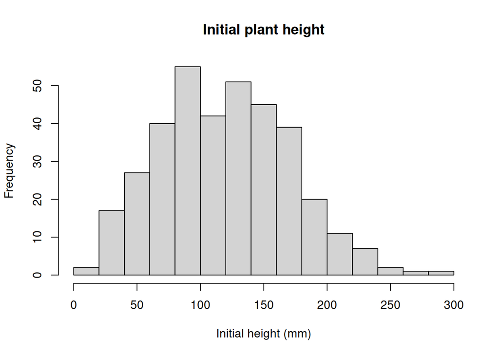

```
##
##  Shapiro-Wilk normality test
##
## data:  x
## W = 0.98997, p-value = 0.01452
```

```r
check_normality(data$P_height,   "Initial plant height",      "Initial height (mm)")
```

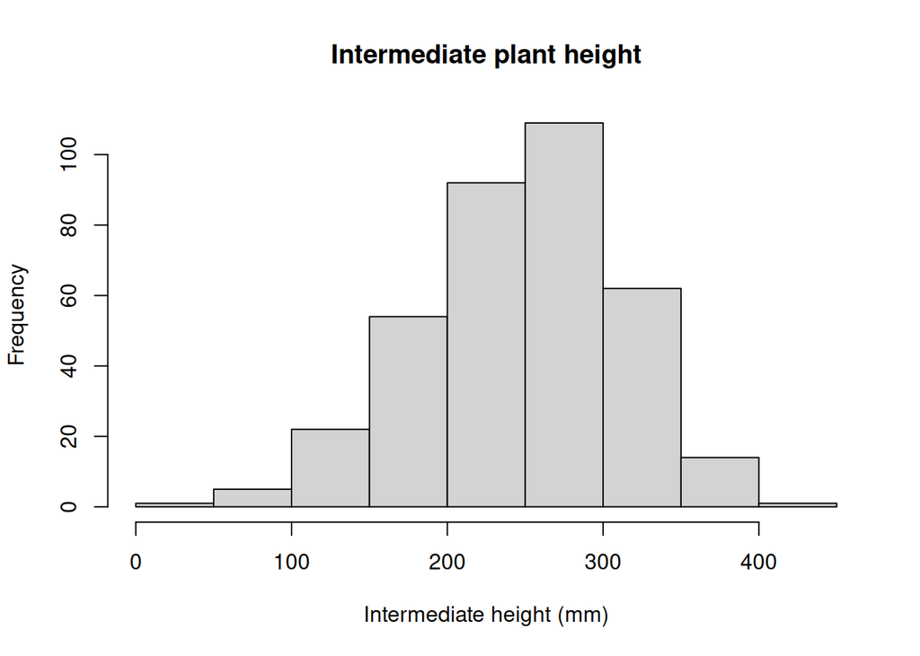

```
##
##  Shapiro-Wilk normality test
##
## data:  x
## W = 0.99172, p-value = 0.04188
```

```r
check_normality(data$P_height_2, "Intermediate plant height", "Intermediate height (mm)")
```

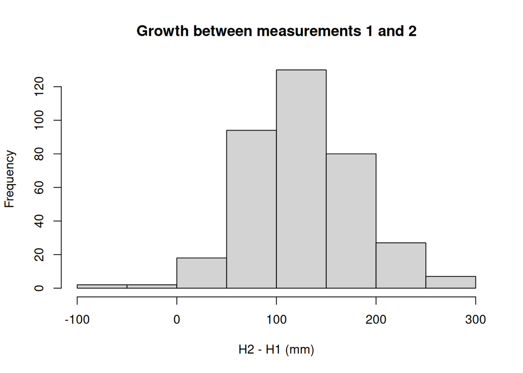

```
##
##  Shapiro-Wilk normality test
##
## data:  x
## W = 0.99005, p-value = 0.01529
```

```r
check_normality(data$H1_H2,      "Growth between measurements 1 and 2", "H2 - H1 (mm)")
```

None of the height variables are normally distributed.

## Leaves

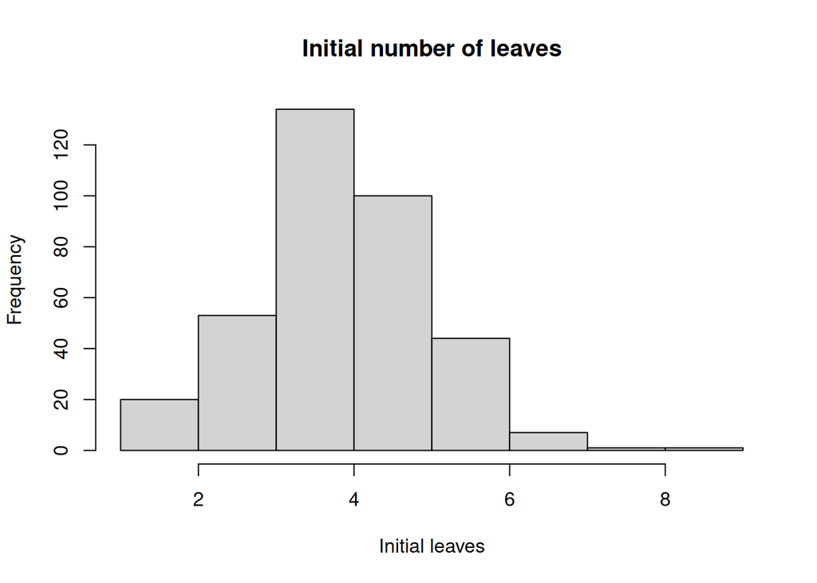

```
##
##  Shapiro-Wilk normality test
##
## data:  x
## W = 0.93188, p-value = 9.211e-12
```

```r
check_normality(data$P_leaves,   "Initial number of leaves",      "Initial leaves")
```

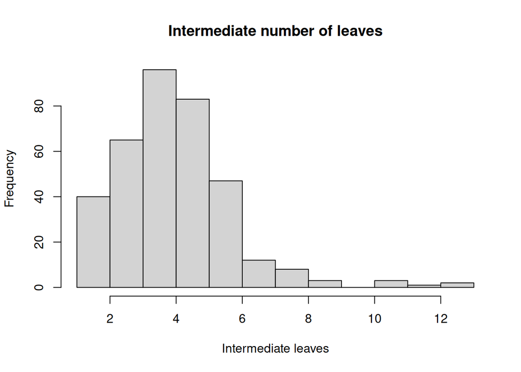

```
##
##  Shapiro-Wilk normality test
##
## data:  x
## W = 0.88744, p-value = 1.319e-15
```

```r
check_normality(data$P_leaves_2, "Intermediate number of leaves", "Intermediate leaves")
```

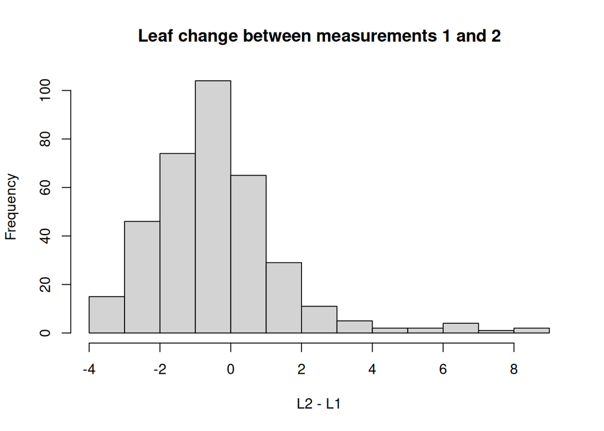

```
##
##  Shapiro-Wilk normality test
##
## data:  x
## W = 0.88567, p-value = 9.797e-16
```

```r
check_normality(data$L1_L2,      "Leaf change between measurements 1 and 2", "L2 - L1")
```

None of the leaf variables are normally distributed.

# Models

**Note on main effects.** With R’s default treatment contrasts, the Type III test of a main effect in a model with an interaction tests that effect at the reference level of the other factor only (bean mites for fertiliser, control plants for mite origin). The overall effects below are therefore taken from estimated marginal means (`emmeans`): the effect is first estimated in each group, and the average effect is the mean of those group effects. Each model shows this calculation step by step.

## Height

**Model 1:** Height ~ Initial height + Nutrient × Mite origin + (1 | Week/Ecosystem)

```r
model1 <- lmer(Height ~ InHeight + Nutrient * Mite_ID + (1 | Week/Ecosystem), data = dt3)
Anova(model1, type = "III", test.statistic = "F")
```

```
## Analysis of Deviance Table (Type III Wald F tests with Kenward-Roger df)
##
## Response: Height
##                         F Df Df.res  Pr(>F)
## (Intercept)      453.0459  1  29.49 < 2e-16 ***
## InHeight         332.7369  1 704.79 < 2e-16 ***
## Nutrient           6.3389  1  53.39 0.01485 *
## Mite_ID            1.3399  2  53.34 0.27053
## Nutrient:Mite_ID   0.2179  2  52.94 0.80496
## ---
## Signif. codes:  0 '***' 0.001 '**' 0.01 '*' 0.05 '.' 0.1 ' ' 1
```

```r
summary(model1)
```

```
## Linear mixed model fit by REML ['lmerMod']
## Formula: Height ~ InHeight + Nutrient * Mite_ID + (1 | Week/Ecosystem)
##    Data: dt3
##
## REML criterion at convergence: 7714.4
##
## Scaled residuals:
##     Min      1Q  Median      3Q     Max
## -4.7371 -0.6685 -0.0143  0.7272  2.9660
##
## Random effects:
##  Groups         Name        Variance Std.Dev.
##  Ecosystem:Week (Intercept)  103.261 10.162
##  Week           (Intercept)    6.679  2.584
##  Residual                   2675.370 51.724
## Number of obs: 720, groups:  Ecosystem:Week, 60; Week, 2
##
## Fixed effects:
##                        Estimate Std. Error t value
## (Intercept)           154.25670    7.23883  21.310
## InHeight                0.71678    0.03915  18.309
## NutrientF              20.39893    8.10194   2.518
## Mite_IDM(t)           -11.92519    8.09429  -1.473
## Mite_IDNo              -1.00894    8.12172  -0.124
## NutrientF:Mite_IDM(t)  -3.79539   11.42545  -0.332
## NutrientF:Mite_IDNo    -7.55068   11.43893  -0.660
##
## Correlation of Fixed Effects:
##             (Intr) InHght NtrntF M_IDM( Mt_IDN NF:M_IDM
## InHeight    -0.560
## NutrientF   -0.512 -0.078
## Mite_IDM(t) -0.520 -0.065  0.502
## Mite_IDNo   -0.496 -0.105  0.504  0.503
## NtF:M_IDM()  0.383  0.021 -0.706 -0.707 -0.354
## NtrnF:M_IDN  0.364  0.053 -0.708 -0.356 -0.708  0.500
```

```r
means_height <- as.data.frame(emmeans(model1, specs = pairwise ~ Nutrient * Mite_ID)$emmeans)
means_height
```

```
##  Nutrient Mite_ID   emmean       SE    df lower.CL upper.CL
##  C        M(b)    240.0876 6.030303 14.52 227.1972 252.9781
##  F        M(b)    260.4866 5.996702 14.21 247.6425 273.3306
##  C        M(t)    228.1625 5.997683 14.22 215.3171 241.0078
##  F        M(t)    244.7660 6.003476 14.27 231.9127 257.6193
##  C        No      239.0787 6.000603 14.24 226.2293 251.9281
##  F        No      251.9270 6.001658 14.25 239.0761 264.7778
##
## Degrees-of-freedom method: kenward-roger
## Confidence level used: 0.95
```

```r
# 1. Effect in each group
by_group <- as.data.frame(pairs(emmeans(model1, ~ Nutrient | Mite_ID)))
by_group$effect <- -by_group$estimate
by_group[, c("Mite_ID", "effect", "p.value")]
```

```
##   Mite_ID   effect    p.value
## 1    M(b) 20.39893 0.01484555
## 2    M(t) 16.60354 0.04500383
## 3      No 12.84825 0.11765401
```

```r
# 2. Average effect by hand: the mean of the group effects
mean(by_group$effect)
```

```
## [1] 16.61691
```

```r
# 3. The same average with emmeans, which also gives the P value
pairs(emmeans(model1, ~ Nutrient))
```

```
##  contrast estimate   SE   df t.ratio p.value
##  C - F       -16.6 4.68 53.4  -3.553  0.0008
##
## Results are averaged over the levels of: Mite_ID
## Degrees-of-freedom method: kenward-roger
```

**Results**

- Initial height: P < 2e-16 (estimate = 0.717)
- Fertiliser within each mite group: +20.4 mm with bean mites (P = 0.015), +16.6 mm with tomato mites (P = 0.045), +12.8 mm without mites (P = 0.12)
- Fertiliser, averaged over mite groups: (20.4 + 16.6 + 12.8) / 3 = +16.6 mm (P = 0.0008)
- Fertiliser × mite origin: not significant (P = 0.80)

**Conclusion.** Plants that started taller stayed taller: each extra mm of initial height predicted about 0.7 mm more height later. Fertiliser increased height by about 17 mm on average compared with control plants.

From the plots, plants with mites from tomato were the smallest and plants with mites from bean the tallest. Mites from tomato may be more costly to the plant.

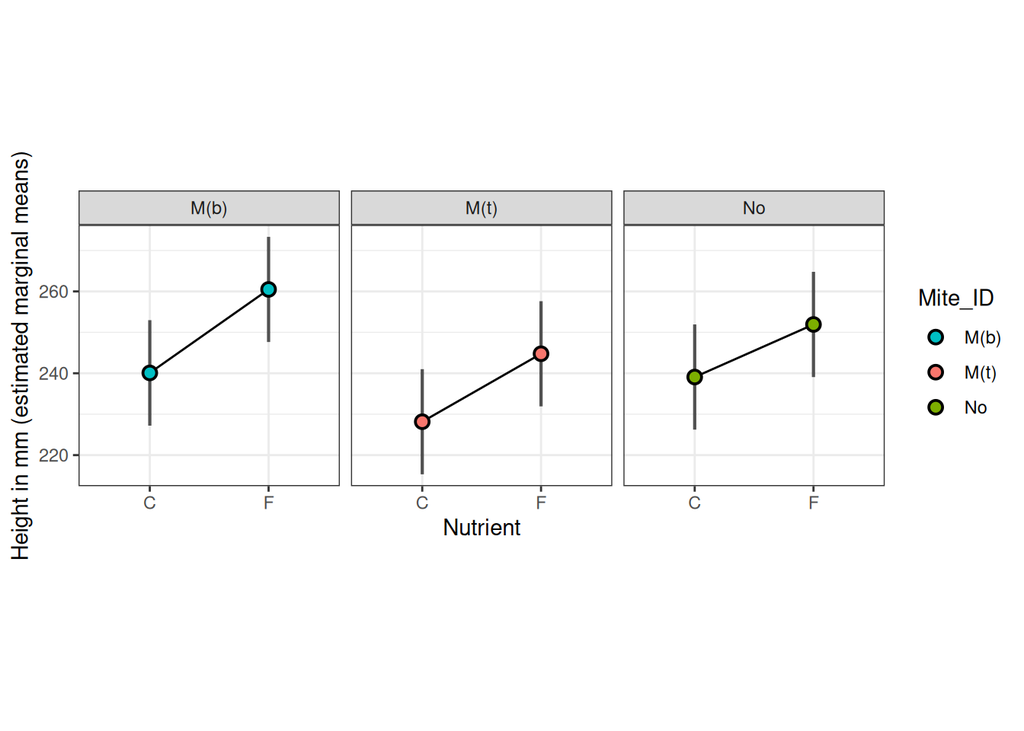

```r
plot_emmeans(means_height, x = "Nutrient", panel = "Mite_ID",
             ylab = "Height in mm (estimated marginal means)")
```

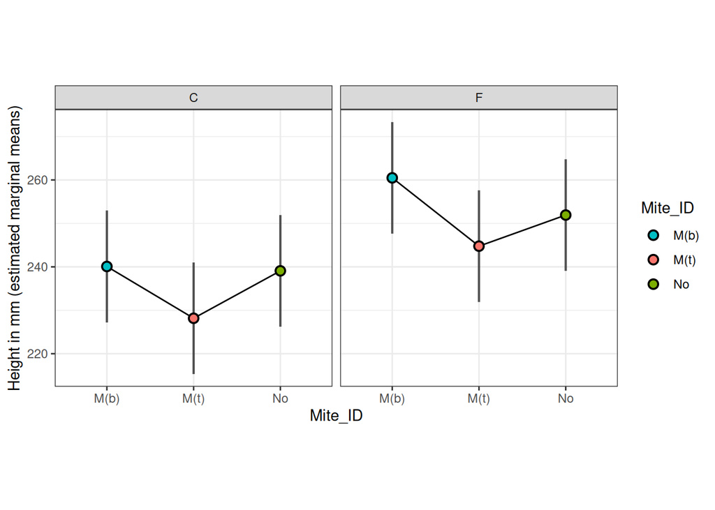

```r
plot_emmeans(means_height, x = "Mite_ID", panel = "Nutrient",
             ylab = "Height in mm (estimated marginal means)")
```

## Leaves

**Model 2:** Leaves ~ Initial leaves + Nutrient × Mite origin + (1 | Week/Ecosystem)

```r
model2 <- lmer(Leaves ~ InLeaves + Nutrient * Mite_ID + (1 | Week/Ecosystem), data = dt3)
Anova(model2, type = "III", test.statistic = "F")
```

```
## Analysis of Deviance Table (Type III Wald F tests with Kenward-Roger df)
##
## Response: Leaves
##                        F Df Df.res    Pr(>F)
## (Intercept)      23.3403  1   4.39 0.0066670 **
## InLeaves         16.1674  1 711.98 6.417e-05 ***
## Nutrient         12.5519  1  52.86 0.0008366 ***
## Mite_ID           2.5536  2  53.36 0.0872768 .
## Nutrient:Mite_ID  5.0930  2  52.97 0.0094827 **
## ---
## Signif. codes:  0 '***' 0.001 '**' 0.01 '*' 0.05 '.' 0.1 ' ' 1
```

```r
summary(model2)
```

```
## Linear mixed model fit by REML ['lmerMod']
## Formula: Leaves ~ InLeaves + Nutrient * Mite_ID + (1 | Week/Ecosystem)
##    Data: dt3
##
## REML criterion at convergence: 3063
##
## Scaled residuals:
##     Min      1Q  Median      3Q     Max
## -2.3265 -0.6394 -0.1069  0.4016  5.2442
##
## Random effects:
##  Groups         Name        Variance Std.Dev.
##  Ecosystem:Week (Intercept) 0.2068   0.4547
##  Week           (Intercept) 0.2024   0.4499
##  Residual                   3.9257   1.9813
## Number of obs: 720, groups:  Ecosystem:Week, 60; Week, 2
##
## Fixed effects:
##                       Estimate Std. Error t value
## (Intercept)            2.32535    0.48088   4.836
## InLeaves               0.26685    0.06618   4.032
## NutrientF              1.15777    0.32679   3.543
## Mite_IDM(t)            0.28385    0.32710   0.868
## Mite_IDNo             -0.45009    0.32845  -1.370
## NutrientF:Mite_IDM(t) -0.39939    0.46252  -0.864
## NutrientF:Mite_IDNo    1.03005    0.46257   2.227
##
## Correlation of Fixed Effects:
##             (Intr) InLevs NtrntF M_IDM( Mt_IDN NF:M_IDM
## InLeaves    -0.576
## NutrientF   -0.336 -0.007
## Mite_IDM(t) -0.314 -0.044  0.500
## Mite_IDNo   -0.280 -0.101  0.498  0.501
## NtF:M_IDM()  0.217  0.041 -0.707 -0.708 -0.356
## NtrnF:M_IDN  0.215  0.043 -0.707 -0.355 -0.707  0.501
```

```r
means_leaves <- as.data.frame(emmeans(model2, specs = pairwise ~ Nutrient * Mite_ID)$emmeans)
means_leaves
```

```
##  Nutrient Mite_ID   emmean        SE   df lower.CL upper.CL
##  C        M(b)    3.483918 0.3933202 1.97 1.765232 5.202604
##  F        M(b)    4.641689 0.3932674 1.97 2.922335 6.361044
##  C        M(t)    3.767767 0.3931989 1.97 2.047546 5.487988
##  F        M(t)    4.526146 0.3933856 1.97 2.808284 6.244008
##  C        No      3.033827 0.3938332 1.98 1.321572 4.746081
##  F        No      5.221653 0.3932114 1.97 3.501590 6.941716
##
## Degrees-of-freedom method: kenward-roger
## Confidence level used: 0.95
```

```r
# Fertiliser effect within each mite group (the interaction is significant)
pairs(emmeans(model2, ~ Nutrient | Mite_ID))
```

```
## Mite_ID = M(b):
##  contrast estimate    SE   df t.ratio p.value
##  C - F      -1.158 0.327 52.9  -3.543  0.0008
##
## Mite_ID = M(t):
##  contrast estimate    SE   df t.ratio p.value
##  C - F      -0.758 0.327 53.1  -2.318  0.0243
##
## Mite_ID = No:
##  contrast estimate    SE   df t.ratio p.value
##  C - F      -2.188 0.327 53.1  -6.685 <0.0001
##
## Degrees-of-freedom method: kenward-roger
```

**Results**

- Initial leaves: P = 6.4e-05 (estimate = 0.27)
- Fertiliser × mite origin: P = 0.0095 (df = 2)
- Fertiliser within each mite group: +2.2 leaves without mites (P < 0.0001), +1.2 with bean mites (P = 0.0008), +0.8 with tomato mites (P = 0.024)

**Conclusion.** Plants with more leaves at the start kept having more leaves (about 0.3 more per initial leaf). Fertilised plants had more leaves in every mite group, but the size of the effect depended on mite origin: about 2.2 more leaves without mites, 1.2 with bean mites and 0.8 with tomato mites. The largest fertiliser effect was in plants without mites, which suggests that mites may counteract the benefit of fertiliser.

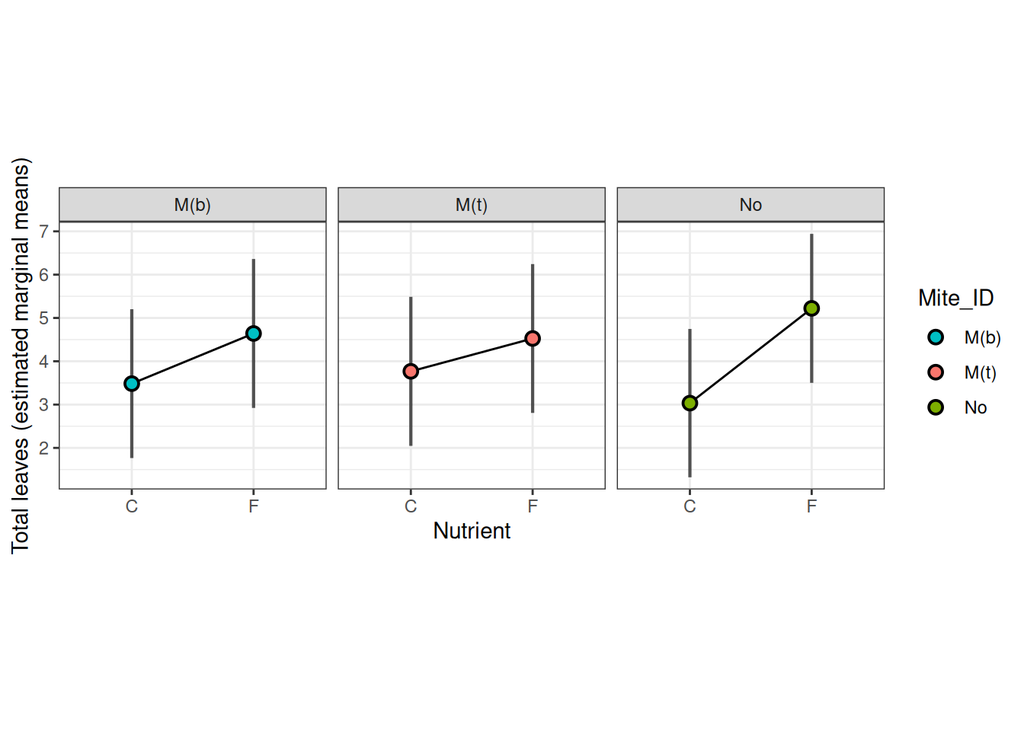

```r
plot_emmeans(means_leaves, x = "Nutrient", panel = "Mite_ID",
             ylab = "Total leaves (estimated marginal means)")
```

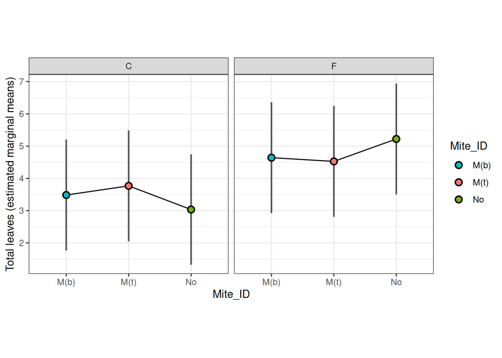

```r
plot_emmeans(means_leaves, x = "Mite_ID", panel = "Nutrient",
             ylab = "Total leaves (estimated marginal means)")
```

## Pistils

**Model 3:** Pistils ~ Nutrient × Mite origin + (1 | Week/Ecosystem)

```r
model3 <- lmer(Pistil ~ Nutrient * Mite_ID + (1 | Week/Ecosystem), data = dt3,
               control = lmerControl(optimizer = "bobyqa"))
Anova(model3, type = "III", test.statistic = "F")
```

```
## Analysis of Deviance Table (Type III Wald F tests with Kenward-Roger df)
##
## Response: Pistil
##                         F Df Df.res    Pr(>F)
## (Intercept)      371.5134  1 24.462 2.672e-16 ***
## Nutrient           9.0193  1 53.000  0.004071 **
## Mite_ID            0.2436  2 53.000  0.784675
## Nutrient:Mite_ID   0.4076  2 53.000  0.667313
## ---
## Signif. codes:  0 '***' 0.001 '**' 0.01 '*' 0.05 '.' 0.1 ' ' 1
```

```r
summary(model3)
```

```
## Linear mixed model fit by REML ['lmerMod']
## Formula: Pistil ~ Nutrient * Mite_ID + (1 | Week/Ecosystem)
##    Data: dt3
## Control: lmerControl(optimizer = "bobyqa")
##
## REML criterion at convergence: 4687.8
##
## Scaled residuals:
##     Min      1Q  Median      3Q     Max
## -2.0701 -0.6549 -0.1861  0.4284  6.6172
##
## Random effects:
##  Groups         Name        Variance Std.Dev.
##  Ecosystem:Week (Intercept)  0.8452  0.9193
##  Week           (Intercept)  0.0000  0.0000
##  Residual                   39.2562  6.2655
## Number of obs: 720, groups:  Ecosystem:Week, 60; Week, 2
##
## Fixed effects:
##                       Estimate Std. Error t value
## (Intercept)            12.3667     0.6416  19.275
## NutrientF               2.7250     0.9074   3.003
## Mite_IDM(t)             0.6167     0.9074   0.680
## Mite_IDNo               0.4333     0.9074   0.478
## NutrientF:Mite_IDM(t)  -1.1583     1.2832  -0.903
## NutrientF:Mite_IDNo    -0.5583     1.2832  -0.435
##
## Correlation of Fixed Effects:
##             (Intr) NtrntF M_IDM( Mt_IDN NF:M_IDM
## NutrientF   -0.707
## Mite_IDM(t) -0.707  0.500
## Mite_IDNo   -0.707  0.500  0.500
## NtF:M_IDM()  0.500 -0.707 -0.707 -0.354
## NtrnF:M_IDN  0.500 -0.707 -0.354 -0.707  0.500
## optimizer (bobyqa) convergence code: 0 (OK)
## boundary (singular) fit: see help('isSingular')
```

```r
means_pistil <- as.data.frame(emmeans(model3, specs = pairwise ~ Nutrient * Mite_ID)$emmeans)
means_pistil
```

```
##  Nutrient Mite_ID   emmean        SE    df lower.CL upper.CL
##  C        M(b)    12.36667 0.6416015 24.46 11.04379 13.68955
##  F        M(b)    15.09167 0.6416015 24.46 13.76879 16.41455
##  C        M(t)    12.98333 0.6416015 24.46 11.66045 14.30621
##  F        M(t)    14.55000 0.6416015 24.46 13.22712 15.87288
##  C        No      12.80000 0.6416015 24.46 11.47712 14.12288
##  F        No      14.96667 0.6416015 24.46 13.64379 16.28955
##
## Degrees-of-freedom method: kenward-roger
## Confidence level used: 0.95
```

```r
# 1. Effect in each group
by_group <- as.data.frame(pairs(emmeans(model3, ~ Nutrient | Mite_ID)))
by_group$effect <- -by_group$estimate
by_group[, c("Mite_ID", "effect", "p.value")]
```

```
##   Mite_ID   effect     p.value
## 1    M(b) 2.725000 0.004070798
## 2    M(t) 1.566667 0.090061497
## 3      No 2.166667 0.020542637
```

```r
# 2. Average effect by hand: the mean of the group effects
mean(by_group$effect)
```

```
## [1] 2.152778
```

```r
# 3. The same average with emmeans, which also gives the P value
pairs(emmeans(model3, ~ Nutrient))
```

```
##  contrast estimate    SE df t.ratio p.value
##  C - F       -2.15 0.524 53  -4.109  0.0001
##
## Results are averaged over the levels of: Mite_ID
## Degrees-of-freedom method: kenward-roger
```

**Results**

- Fertiliser within each mite group: +2.725 with bean mites (P = 0.004), +1.567 with tomato mites (P = 0.090), +2.167 without mites (P = 0.021)
- Fertiliser, averaged over mite groups: (2.725 + 1.567 + 2.167) / 3 = +2.15 pistils (P = 0.0001)
- Fertiliser × mite origin: not significant (P = 0.67)

**Conclusion.** Fertilised plants had about 2 more pistils than control plants, which suggests a higher potential reproductive output.

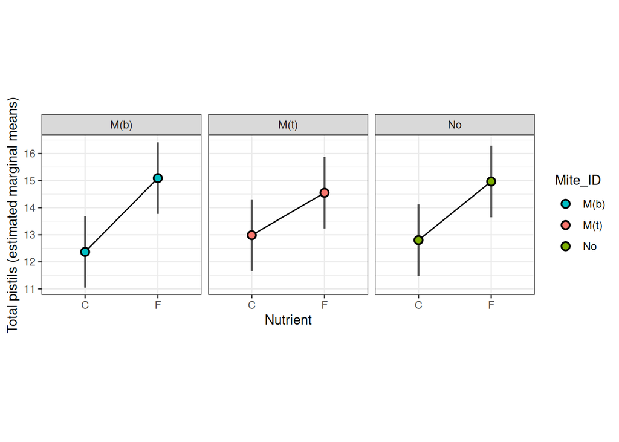

```r
plot_emmeans(means_pistil, x = "Nutrient", panel = "Mite_ID",
             ylab = "Total pistils (estimated marginal means)")
```

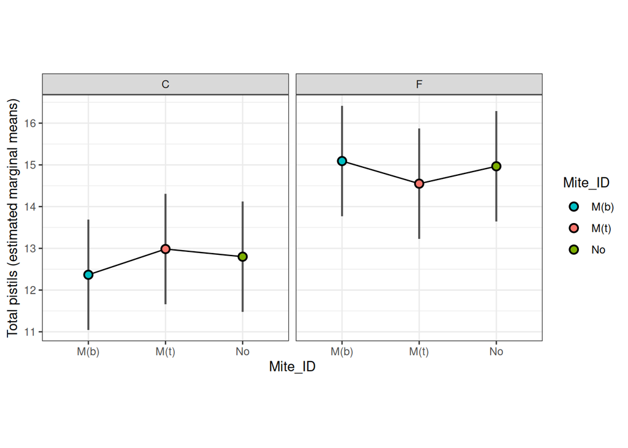

```r
plot_emmeans(means_pistil, x = "Mite_ID", panel = "Nutrient",
             ylab = "Total pistils (estimated marginal means)")
```

## Mites

**Model 4:** Mites ~ Nutrient × Mite origin + (1 | Week/Ecosystem), plants with mites only

```r
model4 <- lmer(Mites ~ Nutrient * Mite_ID + (1 | Week/Ecosystem), data = dt_mites)
Anova(model4, type = "III", test.statistic = "F")
```

```
## Analysis of Deviance Table (Type III Wald F tests with Kenward-Roger df)
##
## Response: Mites
##                        F Df Df.res    Pr(>F)
## (Intercept)      70.3112  1  7.568 4.311e-05 ***
## Nutrient          1.6009  1 35.000   0.21413
## Mite_ID           4.0519  1 35.000   0.05186 .
## Nutrient:Mite_ID  0.0810  1 35.000   0.77757
## ---
## Signif. codes:  0 '***' 0.001 '**' 0.01 '*' 0.05 '.' 0.1 ' ' 1
```

```r
summary(model4)
```

```
## Linear mixed model fit by REML ['lmerMod']
## Formula: Mites ~ Nutrient * Mite_ID + (1 | Week/Ecosystem)
##    Data: dt_mites
##
## REML criterion at convergence: 2992.5
##
## Scaled residuals:
##     Min      1Q  Median      3Q     Max
## -1.6479 -0.6051 -0.1992  0.3721  7.8409
##
## Random effects:
##  Groups         Name        Variance Std.Dev.
##  Ecosystem:Week (Intercept)  2.7703  1.6644
##  Week           (Intercept)  0.1516  0.3893
##  Residual                   28.4812  5.3368
## Number of obs: 480, groups:  Ecosystem:Week, 40; Week, 2
##
## Fixed effects:
##                       Estimate Std. Error t value
## (Intercept)             6.4417     0.7682   8.385
## NutrientF               1.2833     1.0143   1.265
## Mite_IDM(t)            -2.0417     1.0143  -2.013
## NutrientF:Mite_IDM(t)  -0.4083     1.4344  -0.285
##
## Correlation of Fixed Effects:
##             (Intr) NtrntF M_IDM(
## NutrientF   -0.660
## Mite_IDM(t) -0.660  0.500
## NtF:M_IDM()  0.467 -0.707 -0.707
```

```r
means_mites <- as.data.frame(emmeans(model4, specs = pairwise ~ Nutrient * Mite_ID)$emmeans)
means_mites
```

```
##  Nutrient Mite_ID   emmean        SE   df lower.CL upper.CL
##  C        M(b)    6.441667 0.7682207 7.57 4.652380 8.230954
##  F        M(b)    7.725000 0.7682207 7.57 5.935713 9.514287
##  C        M(t)    4.400000 0.7682207 7.57 2.610713 6.189287
##  F        M(t)    5.275000 0.7682207 7.57 3.485713 7.064287
##
## Degrees-of-freedom method: kenward-roger
## Confidence level used: 0.95
```

```r
# 1. Effect in each group
by_group <- as.data.frame(pairs(emmeans(model4, ~ Mite_ID | Nutrient)))
by_group$effect <- by_group$estimate
by_group[, c("Nutrient", "effect", "p.value")]
```

```
##   Nutrient   effect    p.value
## 1        C 2.041667 0.05186461
## 2        F 2.450000 0.02107100
```

```r
# 2. Average effect by hand: the mean of the group effects
mean(by_group$effect)
```

```
## [1] 2.245833
```

```r
# 3. The same average with emmeans, which also gives the P value
pairs(emmeans(model4, ~ Mite_ID))
```

```
##  contrast    estimate    SE df t.ratio p.value
##  M(b) - M(t)     2.25 0.717 35   3.131  0.0035
##
## Results are averaged over the levels of: Nutrient
## Degrees-of-freedom method: kenward-roger
```

```r
# Fertiliser averaged over mite origin
pairs(emmeans(model4, ~ Nutrient))
```

```
##  contrast estimate    SE df t.ratio p.value
##  C - F       -1.08 0.717 35  -1.505  0.1414
##
## Results are averaged over the levels of: Mite_ID
## Degrees-of-freedom method: kenward-roger
```

**Results**

- Mite origin within each fertiliser group: 2.04 fewer tomato than bean mites in control plants (P = 0.052), 2.45 fewer in fertilised plants (P = 0.021)
- Mite origin, averaged over fertiliser: (2.04 + 2.45) / 2 = 2.25 fewer tomato mites (P = 0.0035)
- Fertiliser, averaged over mite origin: no effect (P = 0.14)
- Fertiliser × mite origin: not significant (P = 0.78)

**Conclusion.** Plants carried about 2 fewer mites from tomato than from bean. Fertiliser did not change the number of mites. The Type III test of mite origin (P = 0.052) only compares the two origins in control plants, which is why it looked borderline.

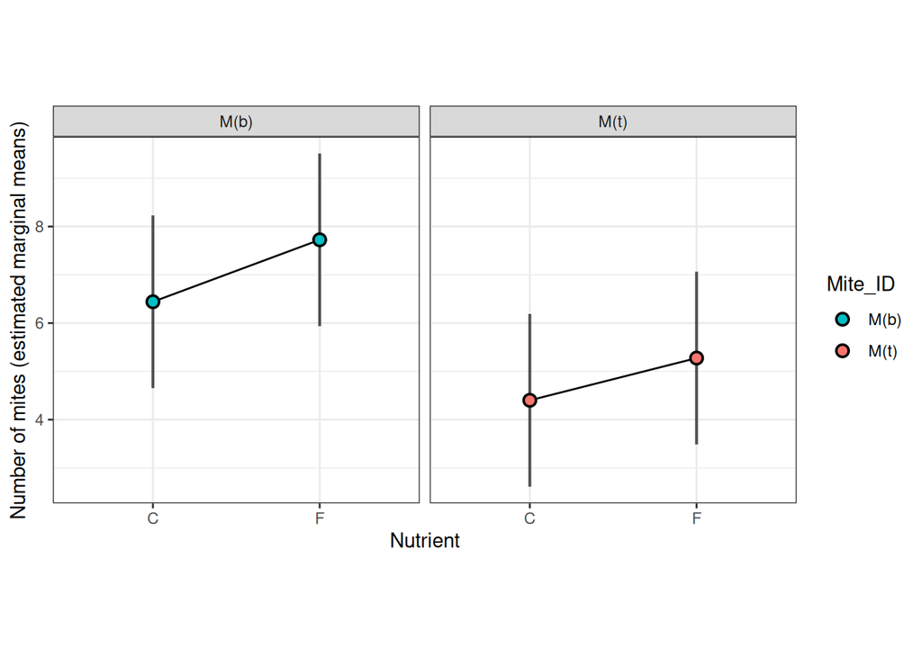

```r
plot_emmeans(means_mites, x = "Nutrient", panel = "Mite_ID",
             ylab = "Number of mites (estimated marginal means)")
```

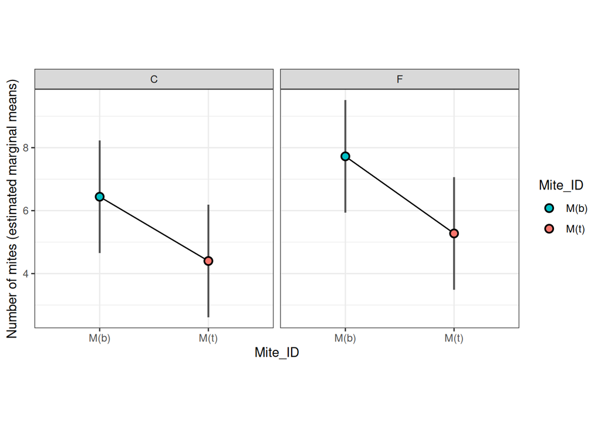

```r
plot_emmeans(means_mites, x = "Mite_ID", panel = "Nutrient",
             ylab = "Number of mites (estimated marginal means)")
```

# Descriptive plots

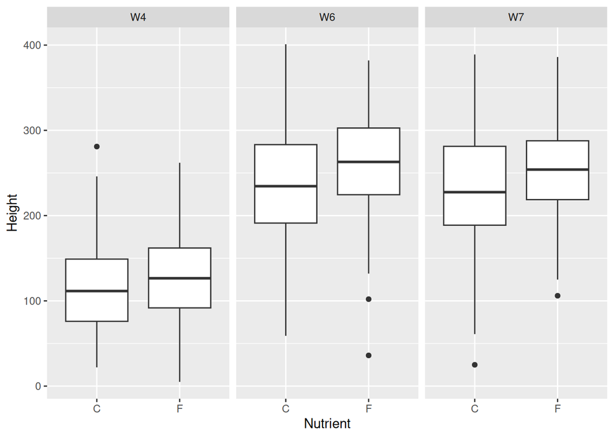

```r
boxplot_by_week <- function(df, y, fill = NULL) {
  mapping <- if (is.null(fill)) aes(x = Nutrient, y = .data[[y]])
             else aes(x = Nutrient, y = .data[[y]], fill = .data[[fill]])
  ggplot(df, mapping) +
    geom_boxplot() +
    facet_grid(cols = vars(Week))
}

boxplot_by_week(dt,  "Height")
```

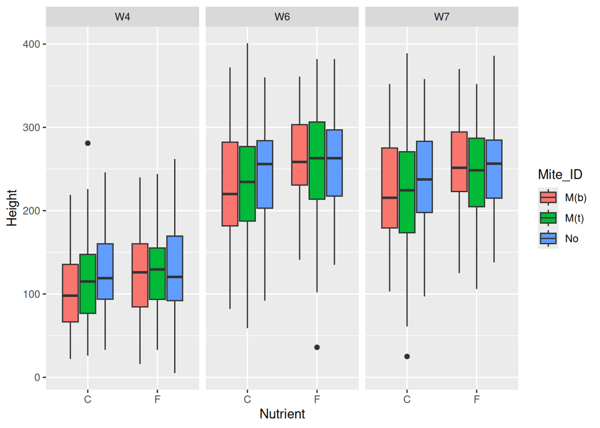

```r
boxplot_by_week(dt,  "Height", fill = "Mite_ID")
```

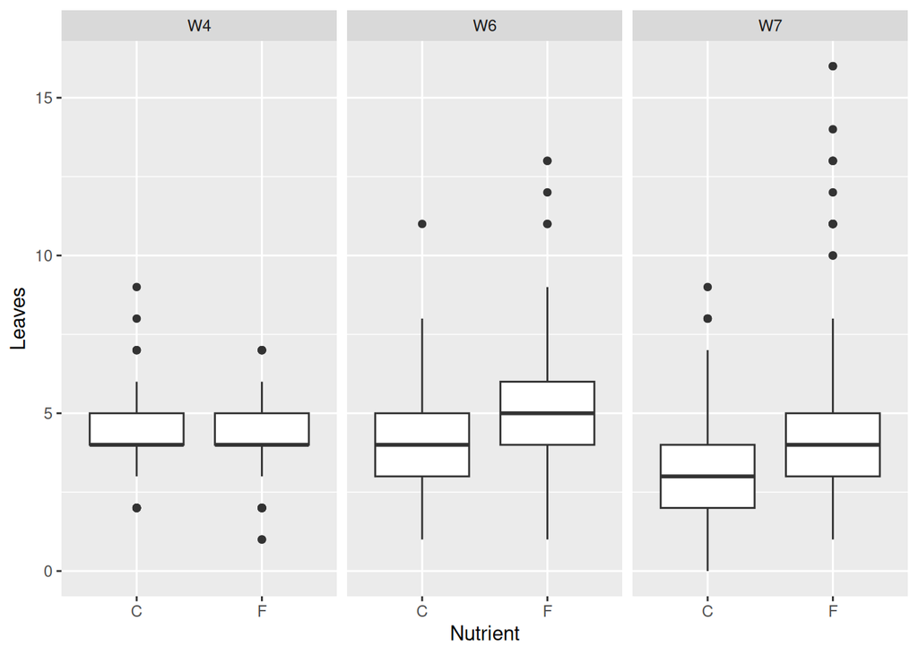

```r
boxplot_by_week(dt,  "Leaves")
```

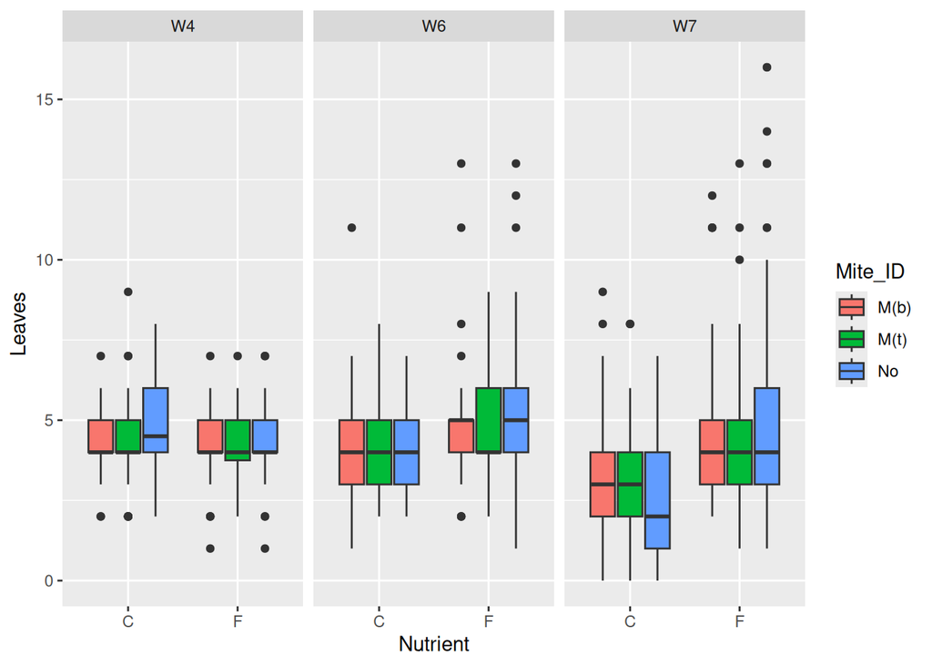

```r
boxplot_by_week(dt,  "Leaves", fill = "Mite_ID")
```

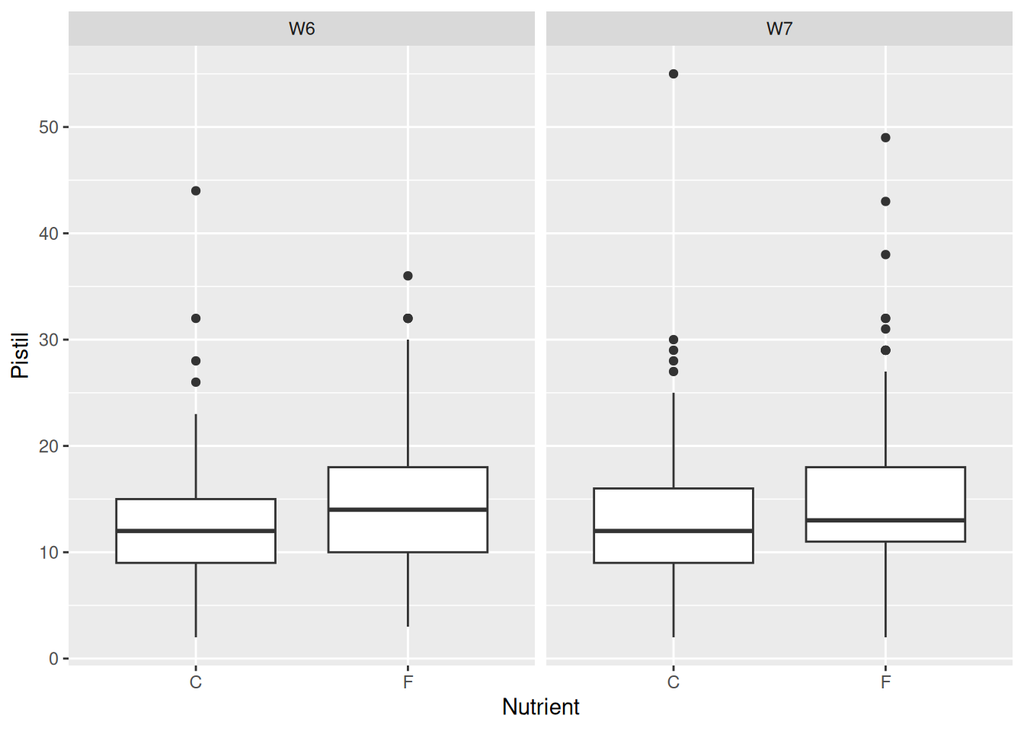

```r
boxplot_by_week(dt2, "Pistil")
```

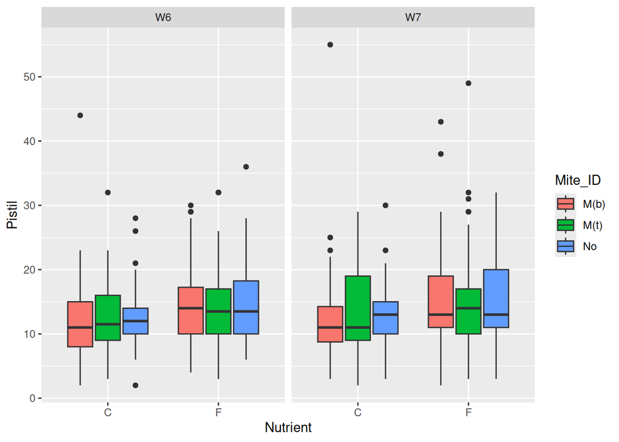

```r
boxplot_by_week(dt2, "Pistil", fill = "Mite_ID")
```

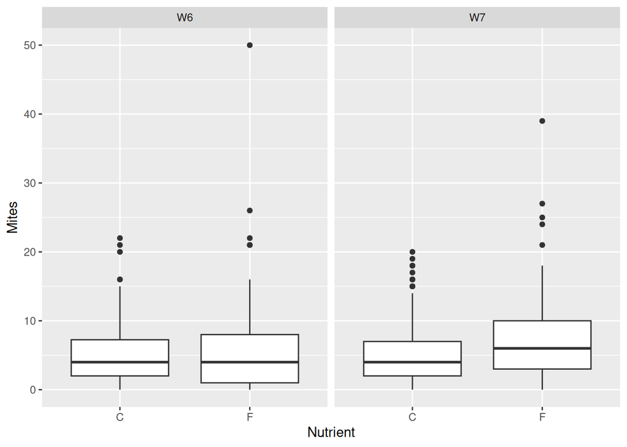

```r
boxplot_by_week(dt2, "Mites")
```

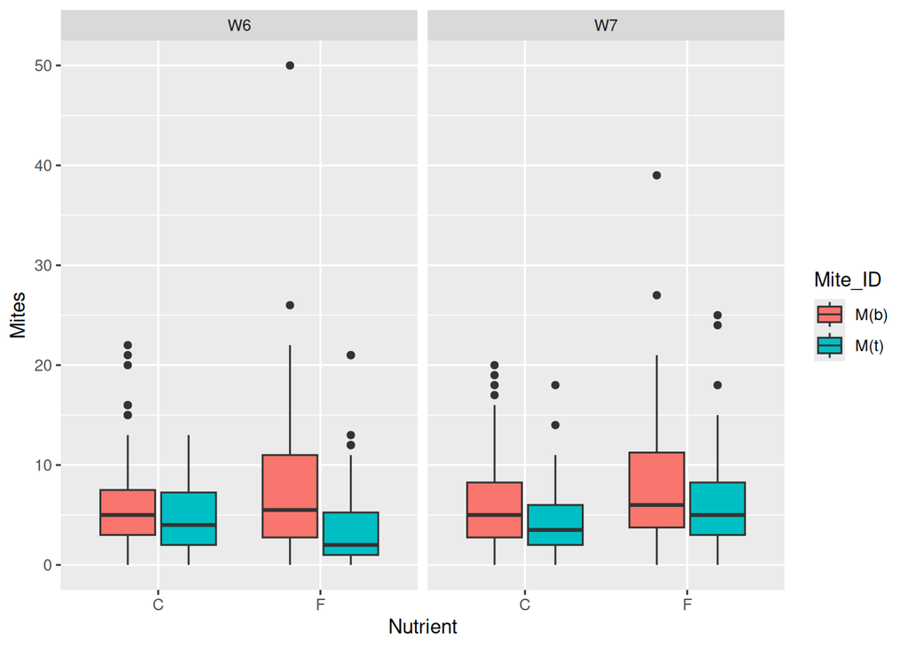

```r
boxplot_by_week(dt2, "Mites",  fill = "Mite_ID")
```

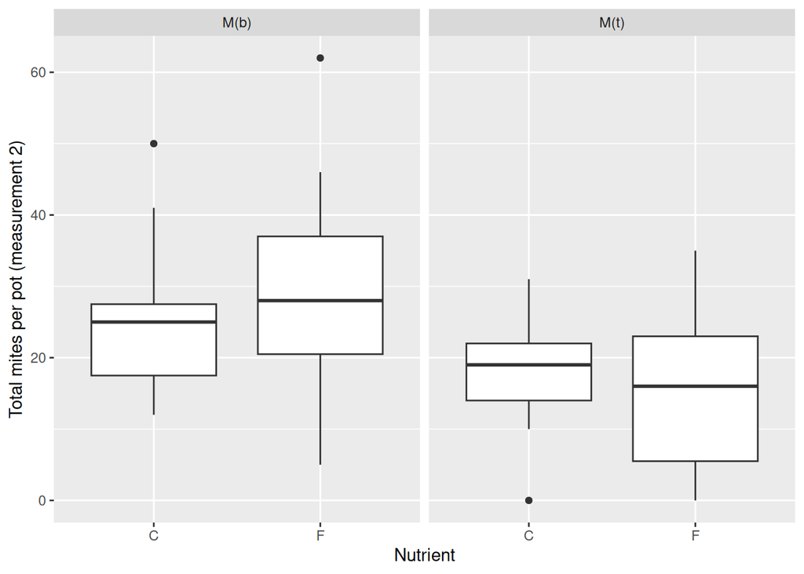

```r
ggplot(count_block, aes(x = Nutrient, y = Mite_total2)) +
  geom_boxplot() + facet_grid(cols = vars(Mite_ID)) +
  ylab("Total mites per pot (measurement 2)")
```

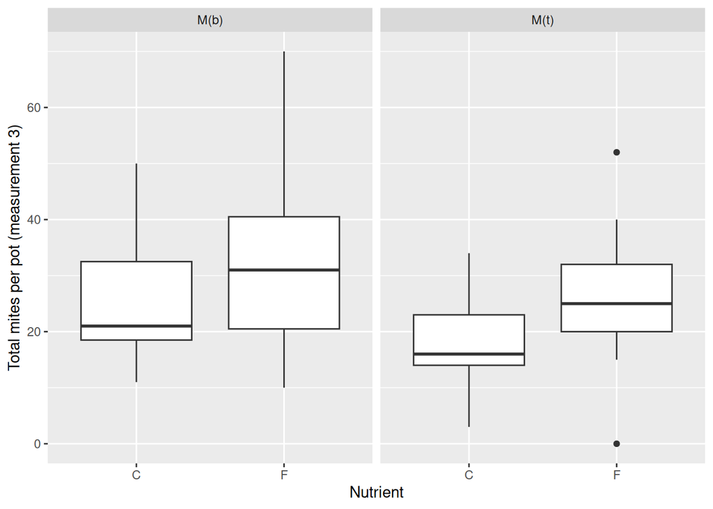

```r
ggplot(count_block, aes(x = Nutrient, y = Mite_total3)) +
  geom_boxplot() + facet_grid(cols = vars(Mite_ID)) +
  ylab("Total mites per pot (measurement 3)")
```